# PS 15 Section 3

### REMINDERS

1. KNIT AS YOU GO!
2. ALWAYS SET YOUR WORKING DIRECTORY FIRST
3. MAKE SURE YOU KNOW WHAT YOUR VARIABLES ARE (X, and Y, ORDER MATTERS)
4. NEVER CODE IN THE CONSOLE (always use the top left panel)
5. KEEP ANSWERS/QUESTIONS SEPARATE FOR EASY READING
1. By this point you should have good grasp of what a working directory is, how it works, and how to set it. You can refer to previous section code for a thorough explanantion of what the working directory is.

```r
# setwd("/home/jovyan/UCSB_POLS15/Section 3")
# Remember to always check what your working directory is!
getwd()
```

```
## [1] "/Users/paashamahdavi/Dropbox/1UCSB/Teaching/PS15 S20/Section materials/Section 3"
```

2. Load the data. Again, because we aren’t using .RData data we use a different function: read.csv. We used this in last week’s section and it is used for importing comma-separated-variable (csv) files. Specify header = T when the first row contains variable names.

```r
terror <- read.csv("terror.csv", header = T)
```

3. Now that the data is imported we can check its structure to make sure it imported correctly and, more importantly, to see what we are dealing with.
1. Dimensionality. We are working with m*n matrices, and dim returns the number of rows (m), as well as the number of columns (n). What are some other ways to check the dimensionality of the data.

```r
dim(terror)
```

```
## [1] 127   8
```

2. Variable names. The following functions will return the variable names used in the dataset. It is often helpful to keep one of the functions somewhere in your script so you can access variable names. It is easy to forget variable names when, for instance, you are working with a dataset that has 200 variables.

```r
names(terror)
```

```
## [1] "X"                   "Country"             "Number.of.Incidents"
## [4] "Percent"             "Number.Killed"       "Number.Injured"
## [7] "Number.US.Killed"    "Number.US.Injured"
```

```r
variable.names(terror)
```

```
## [1] "X"                   "Country"             "Number.of.Incidents"
## [4] "Percent"             "Number.Killed"       "Number.Injured"
## [7] "Number.US.Killed"    "Number.US.Injured"
```

```r
colnames(terror)
```

```
## [1] "X"                   "Country"             "Number.of.Incidents"
## [4] "Percent"             "Number.Killed"       "Number.Injured"
## [7] "Number.US.Killed"    "Number.US.Injured"
```

4. Some descriptives.
1. Range.

```r
range(terror$Number.Killed)
```

```
## [1]    0 1268
```

```r
max(terror$Number.Killed) - min(terror$Number.Killed)
```

```
## [1] 1268
```

2. Variance and Standard Deviation. What is the relationship between variance and standard deviation, and what are some ways to calculate each?

```r
sum((terror$Number.Killed - mean(terror$Number.Killed))^2)/(nrow(terror)-1)
```

```
## [1] 47760.19
```

```r
sqrt(sum((terror$Number.Killed - mean(terror$Number.Killed))^2)/(nrow(terror)-1))
```

```
## [1] 218.541
```

```r
var(terror$Number.Killed)
```

```
## [1] 47760.19
```

```r
sd(terror$Number.Killed)
```

```
## [1] 218.541
```

```r
sd(terror$Number.Killed)^2
```

```
## [1] 47760.19
```

```r
sqrt(var(terror$Number.Killed))
```

```
## [1] 218.541
```

3. Histogram. Trying to make sense of the data points in a vector is a difficult task for the brain. We can get a grasp of the distribution and shape of our data by creating a histogram instead, and it tells us a lot about the data we have.

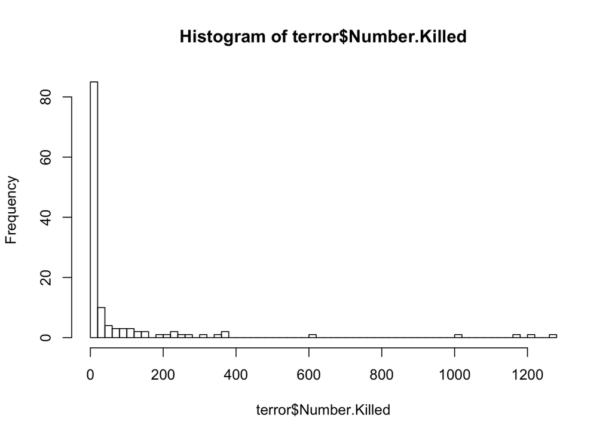

```r
hist(terror$Number.Killed, breaks = 50)
```

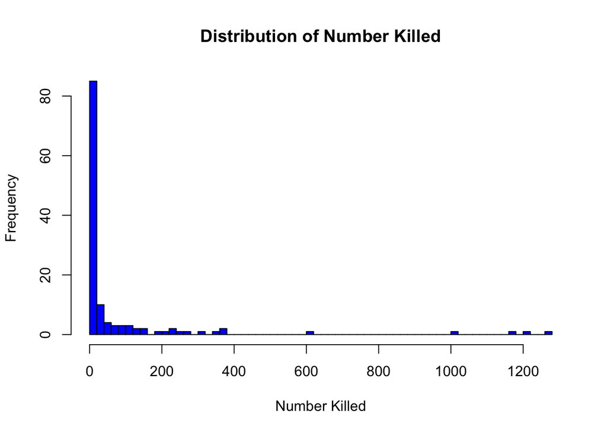

```r
hist(terror$Number.Killed,
     main="Distribution of Number Killed",
     xlab="Number Killed",
     col="blue",
     border="black",
     breaks=50)
```

4. Density and boxplot. A density plot is similar to a histogram, but, in effect, smoothes the data. A boxplot will divide the data into quartiles, showing the range of the data in each quartile. This is also a good way to see which data points are outliers.

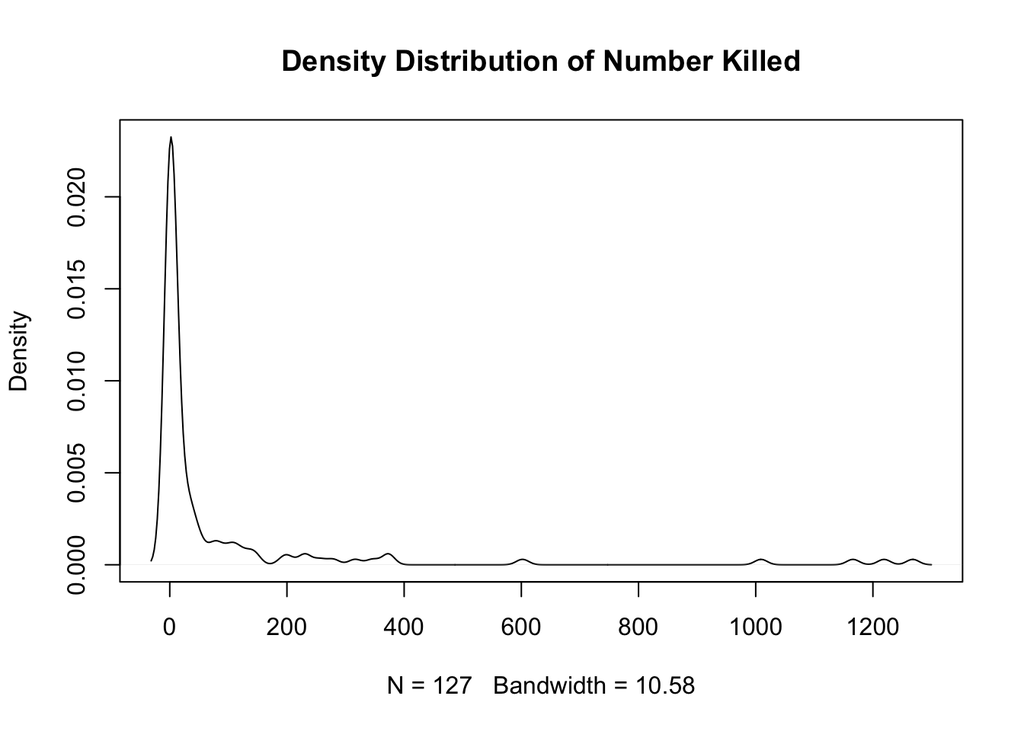

```r
plot(density(terror$Number.Killed),main = "Density Distribution of Number Killed")
```

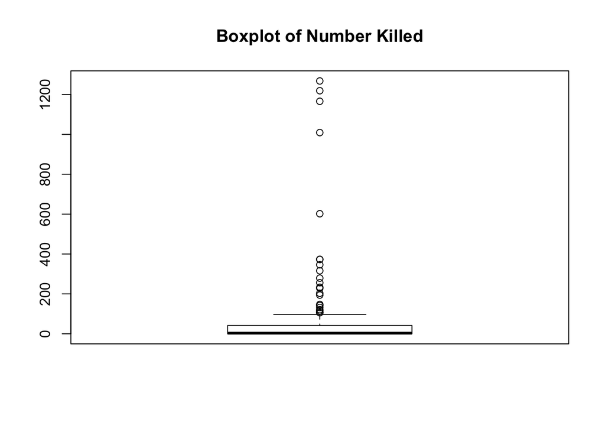

```r
boxplot(terror$Number.Killed, main = "Boxplot of Number Killed")
```

5. Let’s add some descriptive markers to our plots. We will create two vertical lines, one representing the mean, and the other representing the median. Make sure that abline is located directly below the plot, and in the same code chunk. The order in which you label things in the legend matters, so be careful.

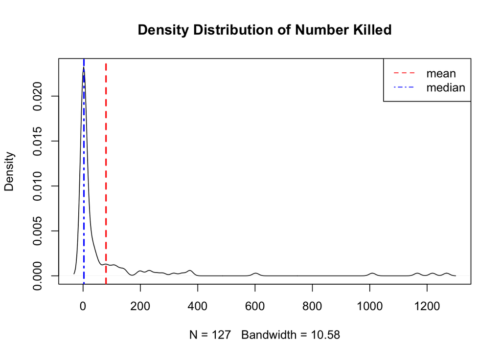

```r
plot(density(terror$Number.Killed), main = "Density Distribution of Number Killed")
abline(v = mean(terror$Number.Killed), lty = 2, lwd = 2, col = "red")
abline(v = median(terror$Number.Killed), lty = 4, lwd = 2, col = "blue")
legend("topright", legend = c("mean", "median"), lty = c(2,4), col = c("red","blue"))
```

5. Computations. We’ll now use R to compute some things. For example, what is the mean number of people killed, conditional on a unit having a number of incidents greater than seven. Conversely, what is the mean number killed for units with a number of incidents less than or equal to 7. What is the difference between the two? We can find this in a number of ways, but, in any case, we need to tell R to subset on a condition. We accomplish this by using square brackets and, in principle, it tells R to look inside a dataframe and select only the units that meet a condition. In words, we are telling R to look inside our dataframe (terror), identify units that have more (less) than seven incidents (which), and assign only those units that satisfy the condition to a new object. We’ll call them high terror (hiterror) and low terror (loterror) countries.

```r
hiterror <- terror[which(terror$Number.of.Incidents>7), ]
loterror <- terror[which(terror$Number.of.Incidents<=7), ]

mean(hiterror$Number.Killed)
```

```
## [1] 162.05
```

```r
mean(loterror$Number.Killed)
```

```
## [1] 6.552239
```

```r
kill.diff <- mean(hiterror$Number.Killed) - mean(loterror$Number.Killed)
kill.diff
```

```
## [1] 155.4978
```

But, we’d rather not create new objects for every computation. Doing so will clutter our working environment, use memory, and we risk overwriting functions and existing objects (this is really bad!). To get around this, we can collapse the above into a single line of code that produces the mean difference. Note that we don’t use which here. Why is that? In any case, look at how much simpler the code is. Also, what is the variance in number killed for high terror units? We can either calculate this directly or use the object we created earlier to generate the estimate.

```r
mean(terror$Number.Killed[terror$Number.of.Incidents>7]) - mean(terror$Number.Killed[terror$Number.of.Incidents<=7])
```

```
## [1] 155.4978
```

```r
var(terror$Number.Killed[terror$Number.of.Incidents>7])
```

```
## [1] 88551.57
```

```r
var(hiterror$Number.Killed)
```

```
## [1] 88551.57
```

6. Plot. Now lets plot the relationship between number of incidents of number killed. Remember that when you are plotting you put the independent variable first and the dependent variable second.

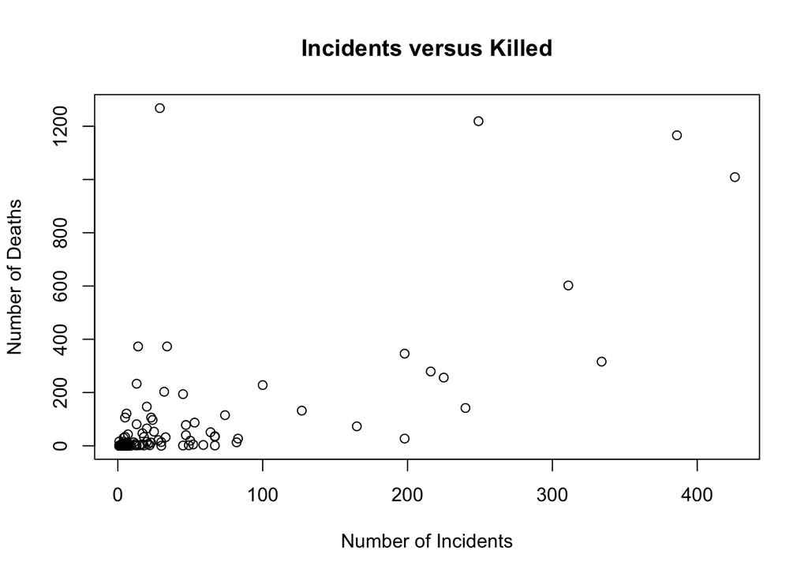

```r
plot(terror$Number.of.Incidents, terror$Number.Killed,
     main="Incidents versus Killed",
     xlab = "Number of Incidents",
     ylab = "Number of Deaths")
```

Is there a pattern to the data? Your guess is as good as mine. To formally test for a relationship between the two variables we can regress our dependent variable on the independent variable using linear regression, check for statistical significance, and add the regression line to our plot. Remember that when using regression in R we list the dependent variable first (left side of the tilde), followed by the independent variable(s) (to the right of the tilde). Also, make sure that your code for the regression line is directly below the plot and in the same code chunk. What is the plot telling us?

```r
model1 <- lm(Number.Killed ~ Number.of.Incidents, data = terror)
summary(model1)
```

```
##
## Call:
## lm(formula = Number.Killed ~ Number.of.Incidents, data = terror)
##
## Residuals:
##     Min      1Q  Median      3Q     Max
## -359.43  -28.64  -10.55   -6.65 1207.27
##
## Coefficients:
##                     Estimate Std. Error t value Pr(>|t|)
## (Intercept)           4.8384    15.7979   0.306     0.76
## Number.of.Incidents   1.9272     0.1816  10.613   <2e-16 ***
## ---
## Signif. codes:  0 '***' 0.001 '**' 0.01 '*' 0.05 '.' 0.1 ' ' 1
##
## Residual standard error: 159.1 on 125 degrees of freedom
## Multiple R-squared:  0.474,  Adjusted R-squared:  0.4698
## F-statistic: 112.6 on 1 and 125 DF,  p-value: < 2.2e-16
```

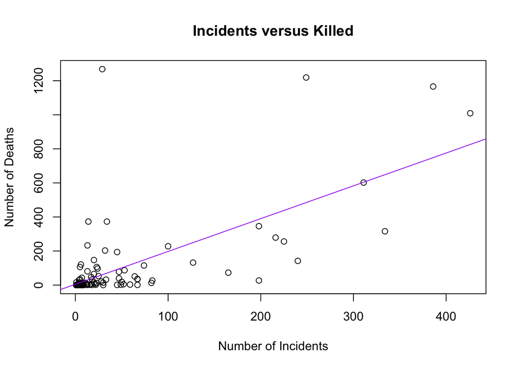

```r
plot(terror$Number.of.Incidents, terror$Number.Killed, main="Incidents versus Killed", xlab = "Number of Incidents", ylab = "Number of Deaths")
abline(model1, col = "purple") #This puts the trend line
```